# AVE_Notebook

En el siguiente documento se va a llevar a cabo un análisis de los datos sobre el ajuste de los precios a lo largo del tiempo que van adoptando los tiques del Renfe AVE, según cambia la oferta y demanda.

Para visualizar como son los datos a analizar, usamos una entrada aleatoria a los datos recuperando 10 filas aleatorias.

```r
renfeDF[sample(nrow(renfeDF), 10),]
```

|  | insert_date | origin | destination | start_date | end_date | train_type | price | train_class | fare |
| --- | --- | --- | --- | --- | --- | --- | --- | --- | --- |
| 702134 | 2019-05-26 19:04:24 | BARCELONA | MADRID | 2019-06-27 14:00:00 | 2019-06-27 17:10:00 | AVE | 75.40 | Turista | Promo |
| 5255877 | 2019-04-30 03:44:59 | MADRID | BARCELONA | 2019-05-22 16:30:00 | 2019-05-22 19:15:00 | AVE | 90.50 | Turista Plus | Promo |
| 5764540 | 2019-05-09 23:31:26 | MADRID | SEVILLA | 2019-07-03 12:00:00 | 2019-07-03 14:32:00 | AVE | 29.00 | Turista | Promo |
| 5943634 | 2019-05-12 09:18:06 | BARCELONA | MADRID | 2019-06-13 10:00:00 | 2019-06-13 13:10:00 | AVE | 85.10 | Turista | Promo |
| 1123496 | 2019-05-31 11:09:57 | MADRID | VALENCIA | 2019-06-03 09:40:00 | 2019-06-03 11:24:00 | AVE | 57.75 | Turista | Promo |
| 2064322 | 2019-06-11 11:26:28 | MADRID | VALENCIA | 2019-06-15 17:40:00 | 2019-06-15 19:20:00 | AVE | 51.15 | Turista | Promo |
| 1600343 | 2019-06-05 21:21:26 | VALENCIA | MADRID | 2019-07-25 18:10:00 | 2019-07-25 19:57:00 | AVE | 57.75 | Turista | Promo |
| 3502608 | 2019-08-14 15:19:34 | MADRID | VALENCIA | 2019-09-16 14:10:00 | 2019-09-16 16:03:00 | AVE | 21.95 | Turista | Promo |
| 674621 | 2019-05-26 11:34:51 | MADRID | VALENCIA | 2019-07-09 16:55:00 | 2019-07-09 19:14:00 | ALVIA | 71.00 | Turista | Flexible |
| 4095949 | 2019-08-22 15:26:20 | MADRID | PONFERRADA | 2019-09-06 14:40:00 | 2019-09-06 20:02:00 | AVE-MD | 59.60 | Turista con enlace | Flexible |

```r
reducedRenfeDF <- renfeDF[sample(nrow(renfeDF), 10000),]
```

```r
library(psych)
describe(renfeDF$price)
```

|  | vars | n | mean | sd | median | trimmed | mad | min | max | range | skew | kurtosis | se |
| --- | --- | --- | --- | --- | --- | --- | --- | --- | --- | --- | --- | --- | --- |
| X1 | 1 | 7098182 | 61.40134 | 25.68525 | 58.15 | 59.61854 | 26.90919 | 12.85 | 342.8 | 329.95 | 0.7518582 | 1.078962 | 0.009640736 |

En este primer analisis podemos determinar la media, mediana, deviacion estandar, kurtosis y el rango de los datos sin discriminar ninguna variable cualitativa. Podemos ver que la mediana de los precios es 58,15 Euros y que el maximo de todos los datos es 342 Euros.

```r
describeBy(renfeDF$price, renfeDF$train_type)
```

```
##
##  Descriptive statistics by group
## group: ALVIA
##    vars      n  mean    sd median trimmed  mad   min  max range skew
## X1    1 420704 55.94 17.39   55.8   55.47 16.9 16.75 92.3 75.55 0.05
##    kurtosis   se
## X1     -0.7 0.03
## --------------------------------------------------------
## group: AV City
##    vars      n  mean   sd median trimmed mad  min  max range skew kurtosis
## X1    1 204552 47.36 7.36  49.15   46.59 8.3 28.6 74.6    46 0.87     0.73
##      se
## X1 0.02
## --------------------------------------------------------
## group: AVE
##    vars       n  mean    sd median trimmed   mad  min   max range skew
## X1    1 5027421 67.98 25.35  66.75   66.97 27.21 14.6 342.8 328.2 0.61
##    kurtosis   se
## X1     1.25 0.01
## --------------------------------------------------------
## group: AVE-LD
##    vars     n  mean    sd median trimmed   mad   min  max range skew
## X1    1 62781 44.79 10.89  42.05   44.84 12.45 16.85 62.4 45.55  0.1
##    kurtosis   se
## X1    -1.25 0.04
## --------------------------------------------------------
## group: AVE-MD
##    vars     n  mean   sd median trimmed  mad   min max range  skew
## X1    1 53220 56.76 13.6   59.6   57.63 16.9 23.85  71 47.15 -0.35
##    kurtosis   se
## X1    -1.35 0.06
## --------------------------------------------------------
## group: AVE-TGV
##    vars      n mean    sd median trimmed   mad  min   max range skew
## X1    1 100575 90.2 19.78   85.1   89.58 19.13 32.3 235.3   203 1.38
##    kurtosis   se
## X1     5.12 0.06
## --------------------------------------------------------
## group: INTERCITY
##    vars      n mean    sd median trimmed   mad   min  max range skew
```

[output cut: 37 more lines]

```
## X1    1 92932 43.25  0  43.25   43.25   0 43.25 43.25     0  NaN      NaN
##    se
## X1  0
## --------------------------------------------------------
## group: REGIONAL
##    vars      n  mean sd median trimmed mad   min   max range skew kurtosis
## X1    1 366302 28.35  0  28.35   28.35   0 28.35 28.35     0  NaN      NaN
##    se
## X1  0
## --------------------------------------------------------
## group: TRENHOTEL
##    vars     n  mean   sd median trimmed mad  min   max range skew kurtosis
## X1    1 82870 47.85 8.46   45.8    45.8   0 45.8 150.6 104.8  5.8    49.86
##      se
## X1 0.03
```

```r
describeBy(renfeDF$price, renfeDF$train_class)
```

```
##
##  Descriptive statistics by group
## group:
## NULL
## --------------------------------------------------------
## group: Cama G. Clase
##    vars   n   mean    sd median trimmed mad  min   max range skew kurtosis
## X1    1 195 145.76 15.21  150.6   150.6   0 98.2 150.6  52.4 -2.8     5.84
##      se
## X1 1.09
## --------------------------------------------------------
## group: Cama Turista
##    vars    n mean sd median trimmed mad  min  max range skew kurtosis se
## X1    1 5309 74.2  0   74.2    74.2   0 74.2 74.2     0  NaN      NaN  0
## --------------------------------------------------------
## group: Preferente
##    vars      n  mean    sd median trimmed   mad  min   max range skew
## X1    1 676294 76.65 30.05   69.4   72.77 25.13 27.7 342.8 315.1 1.72
##    kurtosis   se
## X1     4.28 0.04
## --------------------------------------------------------
## group: PreferenteSólo plaza H
##    vars    n mean    sd median trimmed mad   min  max range  skew kurtosis
## X1    1 5632 81.8 11.11   87.4   83.59   0 52.45 92.3 39.85 -1.38        0
##      se
## X1 0.15
## --------------------------------------------------------
## group: Turista
##    vars       n  mean    sd median trimmed   mad   min   max  range skew
## X1    1 5417142 58.51 24.04   53.4   56.72 29.21 12.85 172.4 159.55 0.55
##    kurtosis   se
## X1    -0.29 0.01
## --------------------------------------------------------
## group: Turista con enlace
##    vars      n  mean    sd median trimmed   mad   min  max range skew
## X1    1 433222 43.82 11.72   40.6   43.15 12.08 16.85 76.4 59.55 0.48
##    kurtosis   se
## X1    -0.66 0.02
## --------------------------------------------------------
## group: Turista Plus
##    vars      n  mean    sd median trimmed   mad   min   max  range  skew
## X1    1 517753 83.79 21.03   90.5   86.04 15.34 15.45 206.8 191.35 -0.92
##    kurtosis   se
## X1     1.78 0.03
## --------------------------------------------------------
## group: Turista PlusSólo plaza H
##    vars  n mean sd median trimmed mad  min  max range skew kurtosis se
## X1    1 21 80.6  0   80.6    80.6   0 80.6 80.6     0  NaN      NaN  0
## --------------------------------------------------------
## group: TuristaSólo plaza H
##    vars     n  mean    sd median trimmed   mad  min   max range skew
## X1    1 42614 88.64 21.15   76.3   89.03 30.99 22.3 127.1 104.8 0.02
##    kurtosis  se
## X1    -1.23 0.1
```

```r
describeBy(renfeDF$price, months(as.Date(renfeDF$start_date)))
```

```
##
##  Descriptive statistics by group
## group: April
##    vars      n  mean    sd median trimmed  mad  min   max range skew
## X1    1 396844 71.44 29.26   67.2    69.2 23.8 16.6 214.2 197.6 1.14
##    kurtosis   se
## X1     2.36 0.05
## --------------------------------------------------------
## group: August
##    vars      n  mean    sd median trimmed   mad   min   max  range skew
## X1    1 653478 54.28 22.38   53.4    52.5 20.68 12.85 214.2 201.35 0.91
##    kurtosis   se
## X1      1.9 0.03
## --------------------------------------------------------
## group: July
##    vars       n  mean    sd median trimmed   mad   min   max  range skew
## X1    1 1582093 58.05 24.68   53.4   56.42 28.24 12.85 214.2 201.35 0.49
##    kurtosis   se
## X1    -0.72 0.02
## --------------------------------------------------------
## group: June
##    vars       n  mean    sd median trimmed   mad  min   max range skew
## X1    1 1824044 65.13 26.42  61.45   63.65 26.98 14.6 342.8 328.2 0.69
##    kurtosis   se
## X1     1.09 0.02
## --------------------------------------------------------
## group: May
##    vars       n  mean    sd median trimmed   mad   min   max  range skew
## X1    1 2004709 63.85 25.74   60.3   62.39 23.72 15.45 235.3 219.85 0.69
##    kurtosis   se
## X1     1.17 0.02
## --------------------------------------------------------
## group: October
##    vars      n  mean    sd median trimmed   mad   min   max range skew
## X1    1 137269 45.13 15.67   45.3   44.44 18.46 12.85 107.7 94.85 0.33
##    kurtosis   se
## X1    -0.45 0.04
## --------------------------------------------------------
## group: September
##    vars      n  mean    sd median trimmed   mad  min   max range skew
## X1    1 499745 54.42 21.34  51.15   52.82 23.13 16.6 181.5 164.9 0.67
##    kurtosis   se
## X1     0.13 0.03
```

A continuacion vamos a utilizar la libreria fitdistrplus para ver si los datos se pueden asemejar a una distribucion de datos conocida. Para eso utilizamos el comando descdist que nos presenta un grafico de Cullen y Frey.

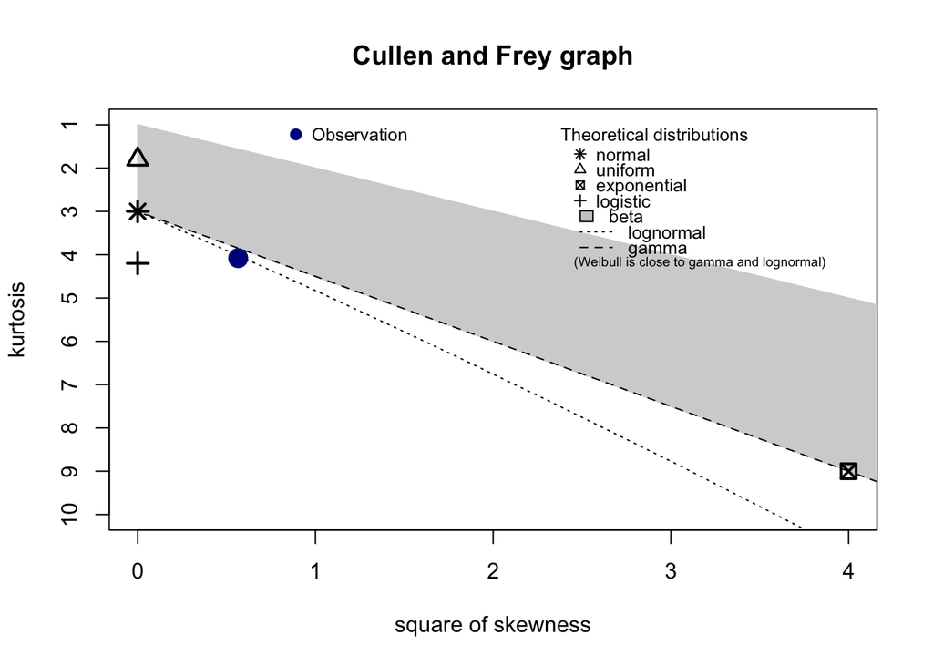

```
## summary statistics
## ------
## min:  12.85   max:  342.8
## median:  58.15
## mean:  61.40134
## estimated sd:  25.68525
## estimated skewness:  0.7518585
## estimated kurtosis:  4.078965
```

```r
library(fitdistrplus)
descdist(renfeDF$price)
```

Vemos que los datos se podrian asemejar a una lognormal o incluso a una distribucion gamma. Vamos a decidir numericamente si los datos se pueden asemejar a una distribucion normal usando el test de Shapiro-Wilkinson.

Aun asi vamos a representar los datos en un histograma para descartar que se trate de una distibucion normal. Para ello usamos la libreria rcompanion.

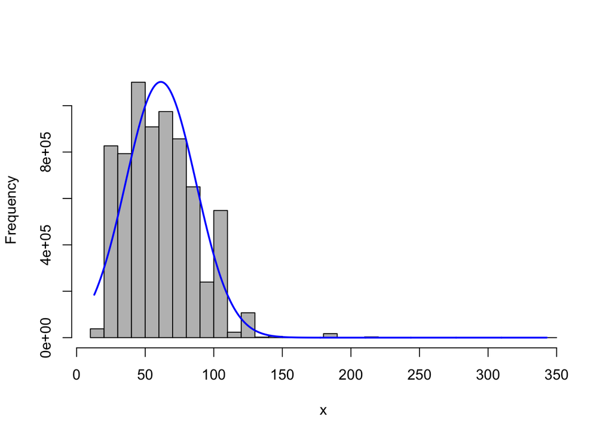

```r
library(rcompanion)
plotNormalHistogram(renfeDF$price)
```

Ahora hacemos el test Shapiro-Wilkinson para tener confirmacion numerica de que no se trata de una normal.

```r
library(fitdistrplus)
shapiro.test(renfeDF$price[1:5000])
```

```
##
##  Shapiro-Wilk normality test
##
## data:  renfeDF$price[1:5000]
## W = 0.95593, p-value < 2.2e-16
```

Podemos asumir que los datos no se asemejan a una normal ya que el p-value obtenido del test de Shapiro-Wilkinson es menor que 0.05.

Ahora vamos a modificar los datos usando una transformacion logaritmica para ver si conseguimos que se asemeje a una distribucion normal.

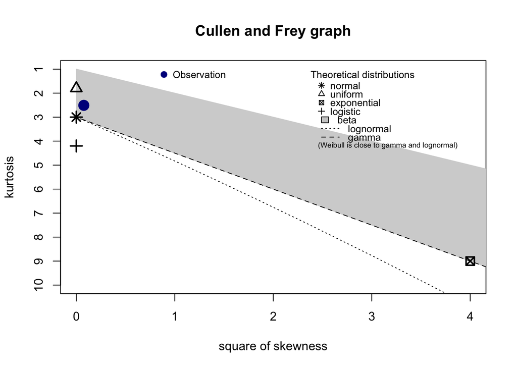

```
## summary statistics
## ------
## min:  2.553344   max:  5.837147
## median:  4.063026
## mean:  4.027099
## estimated sd:  0.4351818
## estimated skewness:  -0.2758038
## estimated kurtosis:  2.508746
```

Al hacer la transformacion de los datos podemos ver que los datos ahora se asemejan a una normal tras realizar una transformacion logaritmica sobre el precio. Ahora mostramos un histograma sobre los datos transformados para ver como se asemeja a una curva normal.

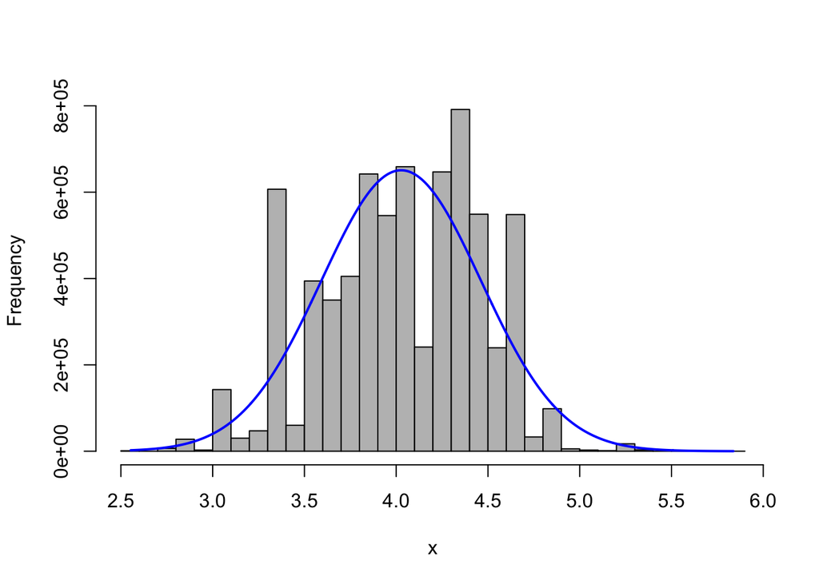

```r
plotNormalHistogram(log(renfeDF$price))
```

Podemos ver que excepto un par de valores que sobresalen por la curva normal, el conjunto de datos se comporta como una curva normal.

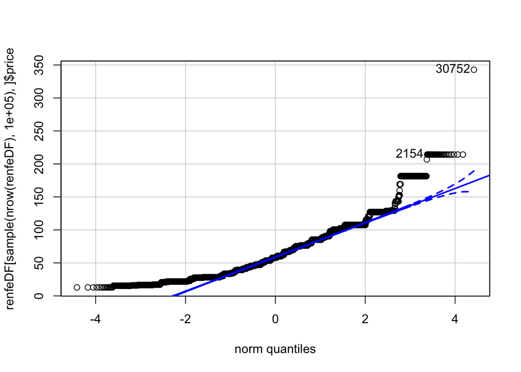

```
## [1] 30752  2154
```

```r
library(car)
qqPlot(renfeDF[sample(nrow(renfeDF), 100000),]$price)
```

Haciendo el Q-Q plot vemos que hay muchos valores que no se asemejan a la recta normal, lo cual concuerda con las previas conclusiones de que los datos de precio, no se asemejan a una distribucion normal. En cambio si repetimos este mismo grafico con una transformacion logaritmica obtenemos unos resultados que se pueden aproximar a una normal. Para ver con mas precision los datos extraemos 100 filas de los datos de manera aleatoria por lo que hacemos 3 veces el mismo grafico para asegurar que los datos de verdad se asemejan a una normal.

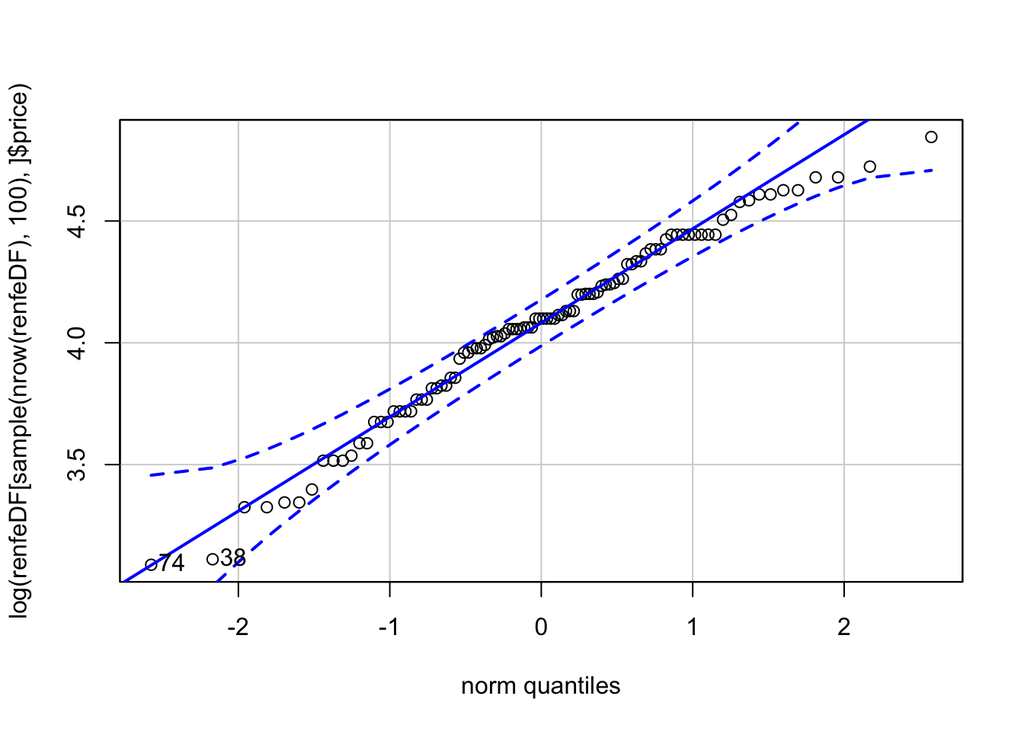

```
## [1] 74 38
```

```r
qqPlot(log(renfeDF[sample(nrow(renfeDF), 100),]$price))
```

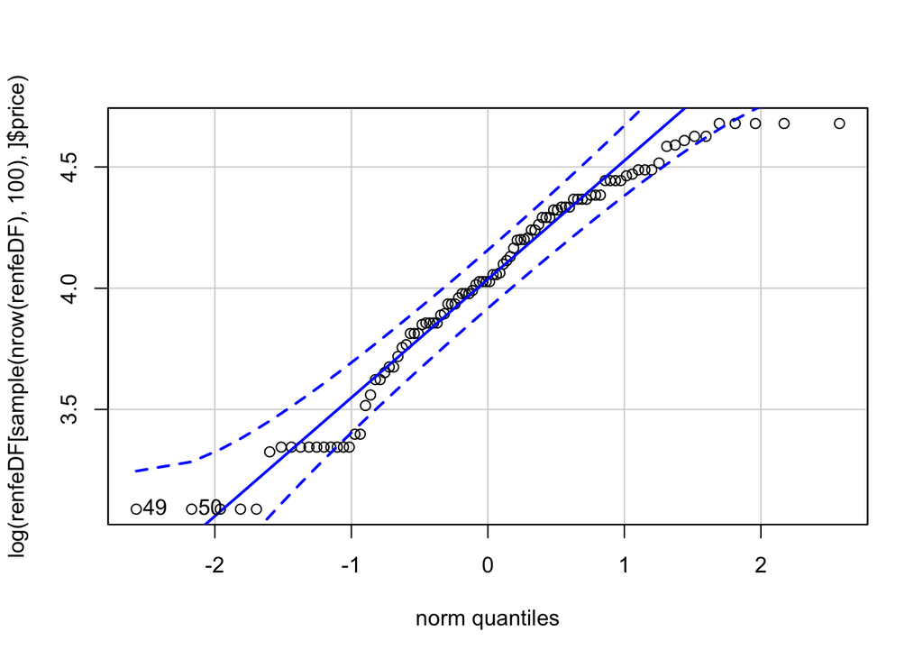

```
## [1] 49 50
```

```r
qqPlot(log(renfeDF[sample(nrow(renfeDF), 100),]$price))
```

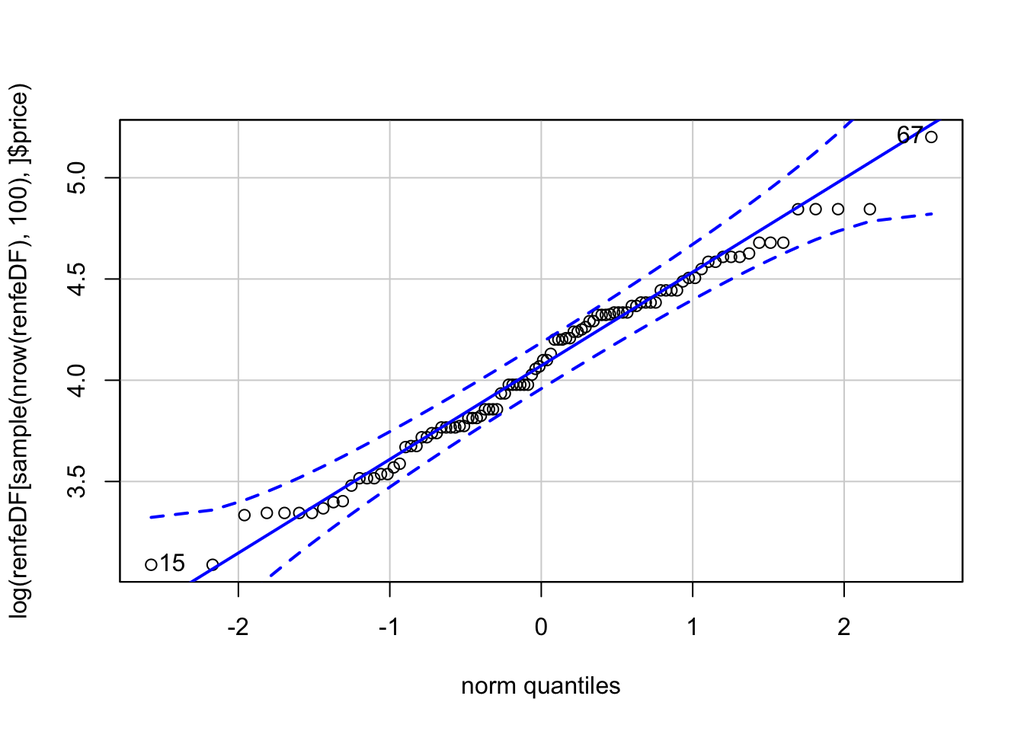

```
## [1] 67 15
```

```r
qqPlot(log(renfeDF[sample(nrow(renfeDF), 100),]$price))
```

Vamos a ver la cantidad de viajes en cada mes

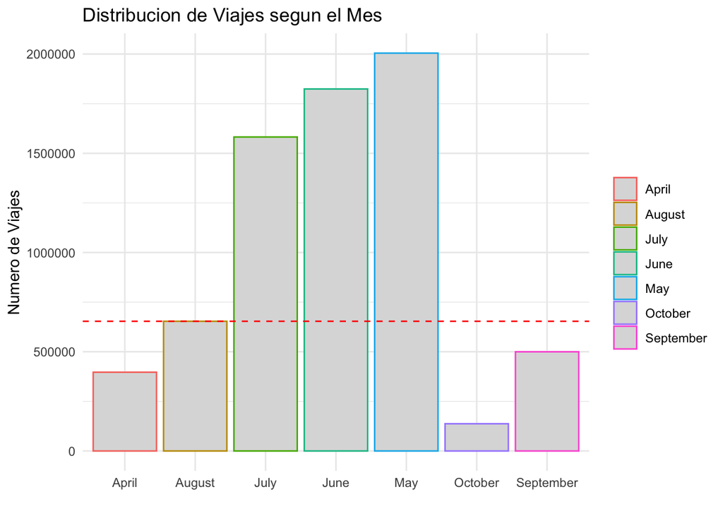

```r
numOfTripsApril <- count(renfeDF %>% filter(months(as.Date(renfeDF$start_date)) == "April" ))
numOfTripsApril <- numOfTripsApril$n
renfeDFApril <- renfeDF %>% filter(months(as.Date(renfeDF$start_date)) == "April")
medianApril <- median(renfeDFApril$price)
numOfTrips <- numOfTripsApril


numOfTripsAugust <- count(renfeDF %>% filter(months(as.Date(renfeDF$start_date)) == "August" ))
numOfTripsAugust <- numOfTripsAugust$n
renfeDFAugust <- renfeDF %>% filter(months(as.Date(renfeDF$start_date)) == "August")
medianAugust <- median(renfeDFAugust$price)
numOfTrips <- c(numOfTrips, numOfTripsAugust)


numOfTripsJuly <- count(renfeDF %>% filter(months(as.Date(renfeDF$start_date)) == "July" ))
numOfTripsJuly <- numOfTripsJuly$n
renfeDFJuly <- renfeDF %>% filter(months(as.Date(renfeDF$start_date)) == "July")
medianJuly <- median(renfeDFJuly$price)
numOfTrips <- c(numOfTrips, numOfTripsJuly)

numOfTripsJune <- count(renfeDF %>% filter(months(as.Date(renfeDF$start_date)) == "June" ))
numOfTripsJune <- numOfTripsJune$n
renfeDFJune <- renfeDF %>% filter(months(as.Date(renfeDF$start_date)) == "June")
medianJune <- median(renfeDFJune$price)
numOfTrips <- c(numOfTrips, numOfTripsJune)


numOfTripsMay <- count(renfeDF %>% filter(months(as.Date(renfeDF$start_date)) == "May" ))
numOfTripsMay <- numOfTripsMay$n
renfeDFMay <- renfeDF %>% filter(months(as.Date(renfeDF$start_date)) == "May")
medianMay <- median(renfeDFMay$price)
numOfTrips <- c(numOfTrips, numOfTripsMay)

numOfTripsOctober <- count(renfeDF %>% filter(months(as.Date(renfeDF$start_date)) == "October" ))
numOfTripsOctober <- numOfTripsOctober$n
renfeDFOctober <- renfeDF %>% filter(months(as.Date(renfeDF$start_date)) == "October")
medianOctober <- median(renfeDFOctober$price)
numOfTrips <- c(numOfTrips, numOfTripsOctober)

numOfTripsSeptember <- count(renfeDF %>% filter(months(as.Date(renfeDF$start_date)) == "September" ))
numOfTripsSeptember <- numOfTripsSeptember$n
renfeDFSeptember <- renfeDF %>% filter(months(as.Date(renfeDF$start_date)) == "September")
medianSeptember <- median(renfeDFSeptember$price)
numOfTrips <- c(numOfTrips, numOfTripsSeptember)

tempDF <- data.frame(numOfTrips, c("April", "August", "July", "June", "May", "October", "September"), c(medianApril,medianAugust,medianJuly,medianJune,medianMay,medianOctober,medianSeptember))
library(tidyverse)
tempDF <- tempDF %>% rename(months=c..April....August....July....June....May....October....September..)
tempDF <- tempDF %>% rename(medianPrice=c.medianApril..medianAugust..medianJuly..medianJune..medianMay..)



h1 <- ggplot(data=tempDF, aes(x=months, y=numOfTrips, color=months)) +
  geom_bar(stat="identity", fill="gray86")
h1 <- h1 + theme_minimal()
h1 <- h1 + ggtitle("Distribucion de Viajes segun el Mes")
h1 <- h1 + geom_hline(yintercept=653478,linetype="dashed",color="red")
h1 <- h1 + labs(y= "Numero de Viajes", x= "", colour="", fill="")
h1
```

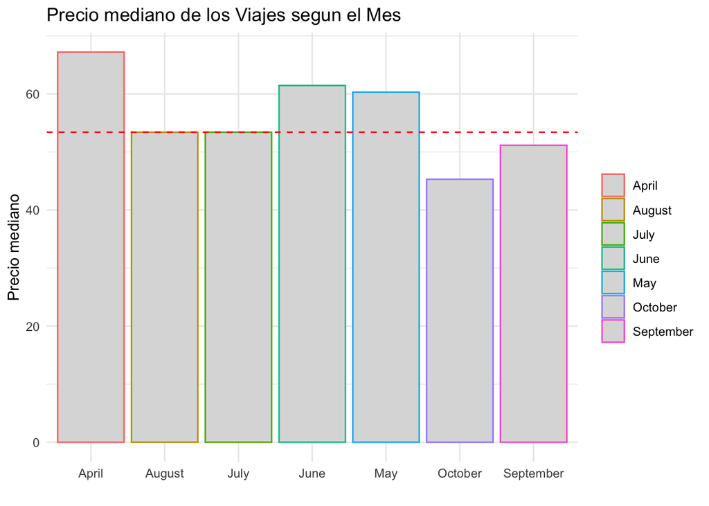

```r
h3 <- ggplot(data=tempDF, aes(x=months, y=medianPrice, color=months)) +
  geom_bar(stat="identity", fill="gray86")
h3 <- h3 + theme_minimal()
h3 <- h3 + geom_hline(yintercept=53.4,linetype="dashed",color="red")
h3 <- h3 + ggtitle("Precio mediano de los Viajes segun el Mes")
h3 <- h3 + labs(y= "Precio mediano", x= "", colour="", fill="")
h3
```

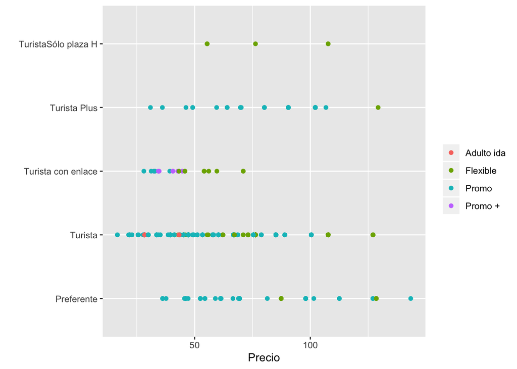

```r
yes <- renfeDF[sample(nrow(renfeDF), 500),]
h2 <- ggplot(yes)
h2 <- h2 + geom_point(aes(x=price,y=train_class,color=fare))
h2 <- h2 + labs(y= "", x= "Precio", colour="", fill="")
h2
```

```r
library(polycor)
hetcor(tempDF)
```

```
##
## Two-Step Estimates
##
## Correlations/Type of Correlation:
##             numOfTrips     months medianPrice
## numOfTrips           1 Polyserial     Pearson
## months        -0.02168          1  Polyserial
## medianPrice      0.388    -0.6569           1
##
## Standard Errors:
##             numOfTrips months
## numOfTrips
## months          0.4182
## medianPrice     0.2877 0.1966
##
## n = 7
##
## P-values for Tests of Bivariate Normality:
##             numOfTrips months
## numOfTrips
## months          0.4919
## medianPrice     0.4625  0.624
```

Vemos que la variable mes afecta mucho mas a la variable precio que la variable numero de viajes.

```r
reducedRenfeDF2 <- data.frame(reducedRenfeDF$origin,reducedRenfeDF$price)
hetcor(reducedRenfeDF2)
```

```
##
## Two-Step Estimates
##
## Correlations/Type of Correlation:
##                       reducedRenfeDF.origin reducedRenfeDF.price
## reducedRenfeDF.origin                     1           Polyserial
## reducedRenfeDF.price                -0.5375                    1
##
## Standard Errors:
## reducedRenfeDF.origin  reducedRenfeDF.price
##                                    0.007339
## Levels:  0.007339
##
## n = 10000
##
## P-values for Tests of Bivariate Normality:
## reducedRenfeDF.origin  reducedRenfeDF.price
##                                           0
## Levels:  0
```

```r
reducedRenfeDF2 <- data.frame(reducedRenfeDF$destination,reducedRenfeDF$price)
hetcor(reducedRenfeDF2)
```

```
##
## Two-Step Estimates
##
## Correlations/Type of Correlation:
##                            reducedRenfeDF.destination reducedRenfeDF.price
## reducedRenfeDF.destination                          1           Polyserial
## reducedRenfeDF.price                          -0.5407                    1
##
## Standard Errors:
## reducedRenfeDF.destination       reducedRenfeDF.price
##                                              0.007356
## Levels:  0.007356
##
## n = 10000
##
## P-values for Tests of Bivariate Normality:
## reducedRenfeDF.destination       reducedRenfeDF.price
##                                                     0
## Levels:  0
```

```r
reducedRenfeDF2 <- data.frame(reducedRenfeDF$destination,reducedRenfeDF$price)
hetcor(reducedRenfeDF2)
```

```
##
## Two-Step Estimates
##
## Correlations/Type of Correlation:
##                            reducedRenfeDF.destination reducedRenfeDF.price
## reducedRenfeDF.destination                          1           Polyserial
## reducedRenfeDF.price                          -0.5407                    1
##
## Standard Errors:
## reducedRenfeDF.destination       reducedRenfeDF.price
##                                              0.007356
## Levels:  0.007356
##
## n = 10000
##
## P-values for Tests of Bivariate Normality:
## reducedRenfeDF.destination       reducedRenfeDF.price
##                                                     0
## Levels:  0
```

```r
library(ggmap)
```

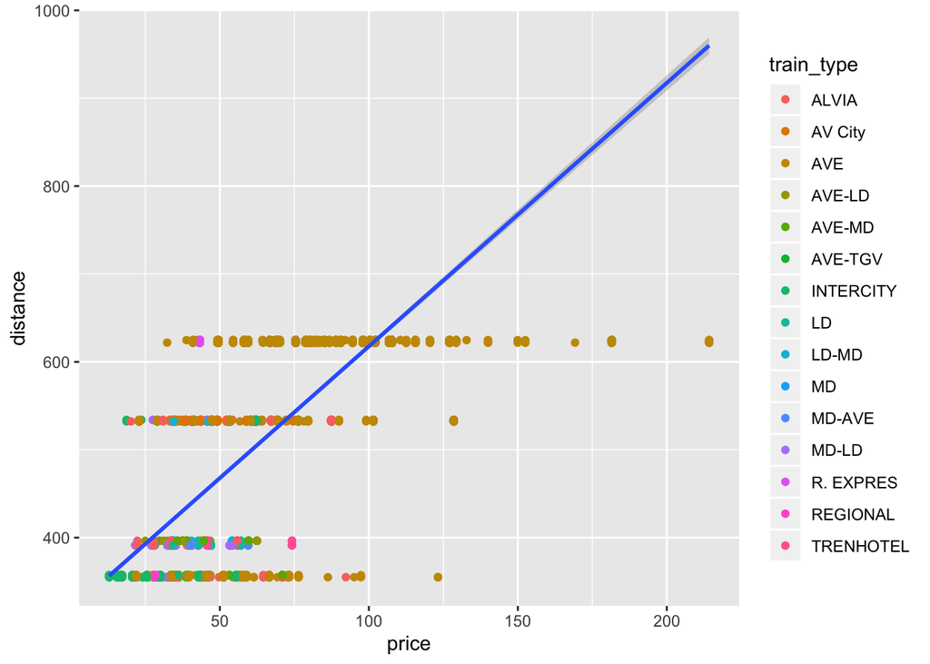

```r
test <- paste(renfeDF$origin,renfeDF$destination)
test <- unique(test)
register_google(key = "AIzaSyBtYqHr5ATL0s8N4BudEH_lS5dGnhV4NNw")
test2 <- str_split(test, " ")

cont <- 1
vectorkm <- c(seq(length(test2)))
while (cont <= length(test2))
{
  it <- test2[[cont]]
  origen <- it[1]
  origen <- paste(origen, ", Spain")
  destino <- it[2]
  destino <- paste(destino, ", Spain")
  dist <- mapdist(from = origen, to = destino)
  vectorkm[cont] <- dist$km
  cont <- cont + 1
}
distances<- data.frame (test,vectorkm)


cont <- 1
tempa <- data.frame()
while(cont <= length(distances$test))
{


  temp<-renfeDF %>% filter(paste(renfeDF$origin,renfeDF$destination)==test[cont])
  temp$distance=distances$vectorkm[cont]
  tempa <- rbind(tempa,temp)
  cont <- cont + 1
}


renfeDF <- tempa
remove(tempa)
reducedRenfeDF <- renfeDF[sample(nrow(renfeDF), 10000),]
h5 <- ggplot(reducedRenfeDF)
h5 <- h5 + geom_point(aes(x=price,y=distance, colour=train_type))
h5 <- h5 + geom_smooth(method= "lm" ,aes(x=price,y=distance))
h5
```

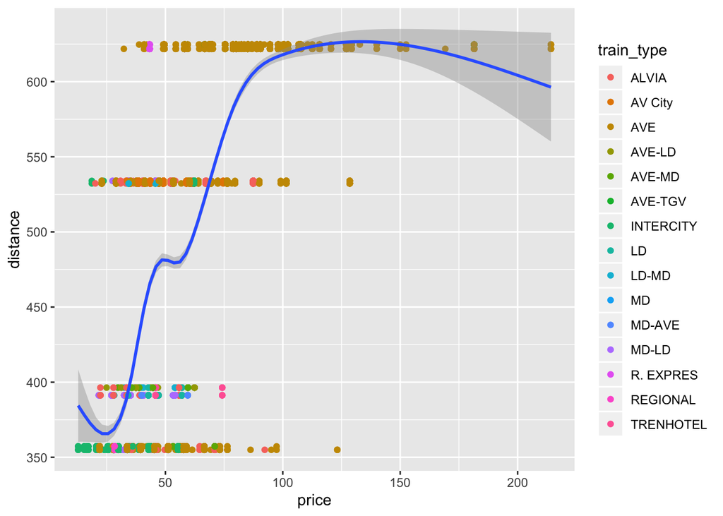

```r
h6 <- ggplot(reducedRenfeDF)
h6 <- h6 + geom_point(aes(x=price,y=distance, colour=train_type))
h6 <- h6 + geom_smooth(aes(x=price,y=distance))
h6
```

Se va a mostrar un scaterplot de la distancia frente al precio para contemplar la distribución que siguen inicialmente:

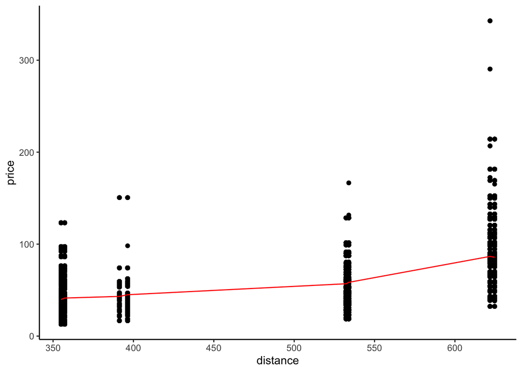

```r
library(ggplot2)
library(tidyverse)
library(caret)
theme_set(theme_classic())

reducedRenfeDF <- renfeDF[sample(nrow(renfeDF), 500000),]

#80& son entrenamiento y 20% test
set.seed(123)
training.samples <- reducedRenfeDF$price %>%
  createDataPartition(p = 0.8, list = FALSE)
train.data  <- reducedRenfeDF[training.samples, ]
test.data <- reducedRenfeDF[-training.samples, ]

ggplot(train.data, aes(distance, price) ) +
  geom_point() +
  stat_summary(fun.y=mean, colour="red", geom="line")
```

Se puede contemplar cómo no forman una distribución lineal, por tanto, se van a realizar modelos de regresión no lineal, para ver el cambio. Se comenzará utilizando una función logarítmica, ya que, se vio anteriormente que se aproximaba el precio a la logarítmica:

```r
library(ggplot2)
library(tidyverse)
library(caret)
theme_set(theme_classic())

set.seed(123)
training.samples <- reducedRenfeDF$price %>%
  createDataPartition(p = 0.8, list = FALSE)
train.data  <- reducedRenfeDF[training.samples, ]
test.data <- reducedRenfeDF[-training.samples, ]

# Build the model
model <- lm(price ~ log(distance), data = train.data)
# Make predictions
predictions <- model %>% predict(test.data)
# Model performance
data.frame(
  RMSE = RMSE(predictions, test.data$price),
  R2 = R2(predictions, test.data$price)
)
```

| RMSE | R2 |
| --- | --- |
| 18.82534 | 0.4669699 |

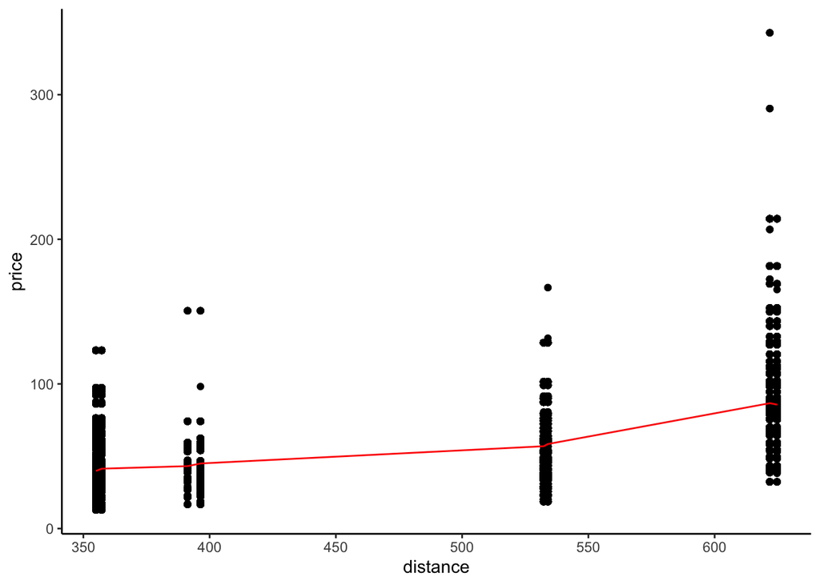

```r
ggplot(train.data, aes(distance, price) ) +
  geom_point() +
  stat_summary(fun.y=mean, colour="red", geom="line")
```

Ahora polynomial

```r
library(ggplot2)
library(tidyverse)
library(caret)
theme_set(theme_classic())


set.seed(123)
training.samples <- reducedRenfeDF$price %>%
  createDataPartition(p = 0.8, list = FALSE)
train.data  <- reducedRenfeDF[training.samples, ]
test.data <- reducedRenfeDF[-training.samples, ]
# Build the model
model <- lm(price ~ poly(distance, 5, raw = TRUE), data = train.data)
# Make predictions
predictions <- model %>% predict(test.data)
# Model performance
data.frame(
  RMSE = RMSE(predictions, test.data$price),
  R2 = R2(predictions, test.data$price)
)
```

| RMSE | R2 |
| --- | --- |
| 17.45112 | 0.5419495 |

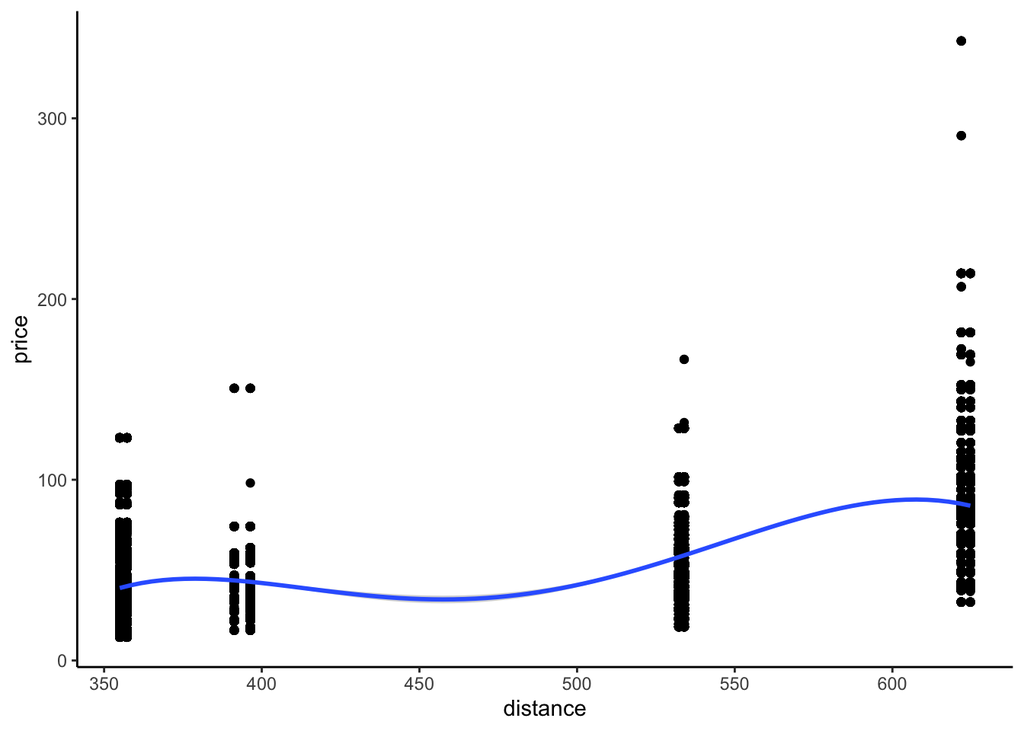

```r
ggplot(train.data, aes(distance, price) ) +
  geom_point() +
  stat_smooth(method = lm, formula = y ~ poly(x, 5, raw = TRUE))
```

```r
library(lubridate)
reducedRenfeDF$insert_date <- ymd_hms(reducedRenfeDF$insert_date)
reducedRenfeDF$start_date <- ymd_hms(reducedRenfeDF$start_date)
reducedRenfeDF$end_date <- ymd_hms(reducedRenfeDF$end_date)
```

Como se vio anteriormente, la variable precio tiene poca relación lineal con el resto de variables. A continuación, se va a mostrar un scaterplot del precio con todas las variables, para ver una representación más clara del suceso anterior:

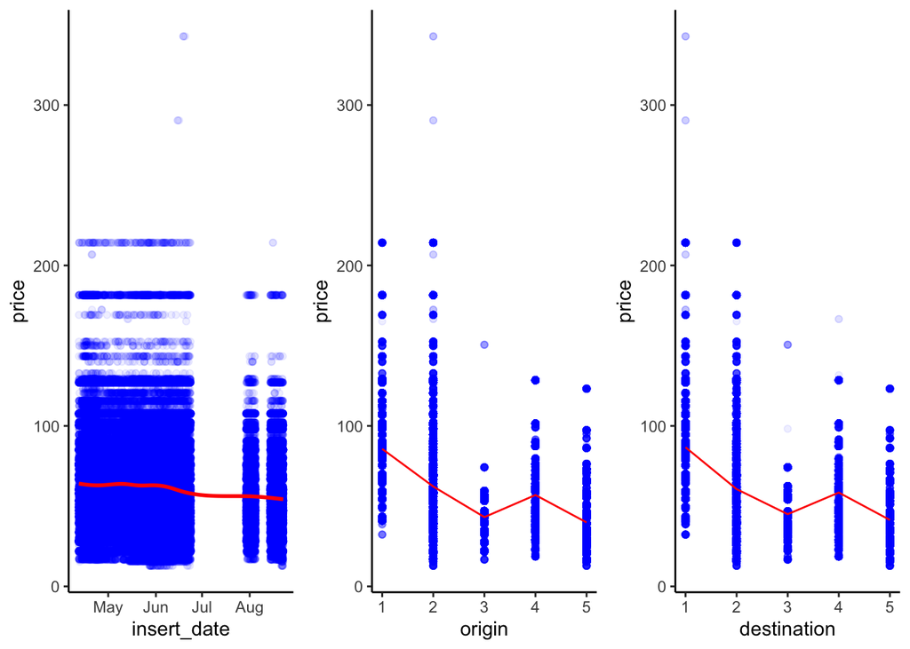

```r
library(ggplot2)
library(tidyverse)
library(caret)
library(grid)
theme_set(theme_classic())

#discretizacion de variables nominales
must_convert<-sapply(reducedRenfeDF,is.factor)       # logical vector telling if a variable needs to be displayed as numeric
renfeDF2<-sapply(reducedRenfeDF[,must_convert],unclass)    # data.frame of all categorical variables now displayed as numeric
reducedRenfeDF2<-cbind(reducedRenfeDF[,!must_convert],renfeDF2)        # complete data.frame with all variables put together


#60& son entrenamiento y 40% test
set.seed(123)
training.samples <- reducedRenfeDF2$price %>%
  createDataPartition(p = 0.8, list = FALSE)
train.data  <- reducedRenfeDF2[training.samples, ]
test.data <- reducedRenfeDF2[-training.samples, ]

remove(renfeDF2)
remove(reducedRenfeDF2)

plot1 <- ggplot(train.data, aes(x=insert_date, y=price) ) +
geom_point(alpha = 1/15, color = 'blue')+
stat_smooth(color = 'Red')

plot2 <- ggplot(train.data, aes(x=origin, y=price) ) +
geom_point(alpha = 1/15, color = 'blue')+
stat_summary(fun.y=mean, colour="red", geom="line")

plot3 <- ggplot(train.data, aes(x=destination, y=price) ) +
geom_point(alpha = 1/15, color = 'blue')+
stat_summary(fun.y=mean, colour="red", geom="line")

plot4 <- ggplot(train.data, aes(x=start_date, y=price) ) +
geom_point(alpha = 1/15, color = 'blue')+
stat_smooth(color = 'Red')

plot5 <- ggplot(train.data, aes(x=end_date, y=price) ) +
geom_point(alpha = 1/15, color = 'blue')+
stat_smooth(color = 'Red')

plot6 <- ggplot(train.data, aes(x=train_type, y=price) ) +
geom_point(alpha = 1/15, color = 'blue')+
stat_summary(fun.y=mean, colour="red", geom="line")

plot7 <- ggplot(train.data, aes(x=train_class, y=price) ) +
geom_point(alpha = 1/15, color = 'blue')+
stat_summary(fun.y=mean, colour="red", geom="line")

plot8 <- ggplot(train.data, aes(x=fare, y=price) ) +
geom_point(alpha = 1/15, color = 'blue')+
stat_summary(fun.y=mean, colour="red", geom="line")

plot9 <- ggplot(train.data, aes(x=distance, y=price) ) +
geom_point(alpha = 1/15, color = 'blue')+
stat_summary(fun.y=mean, colour="red", geom="line")

library(gridExtra)
grid.arrange(plot1, plot2, plot3, ncol=3, nrow=1)
```

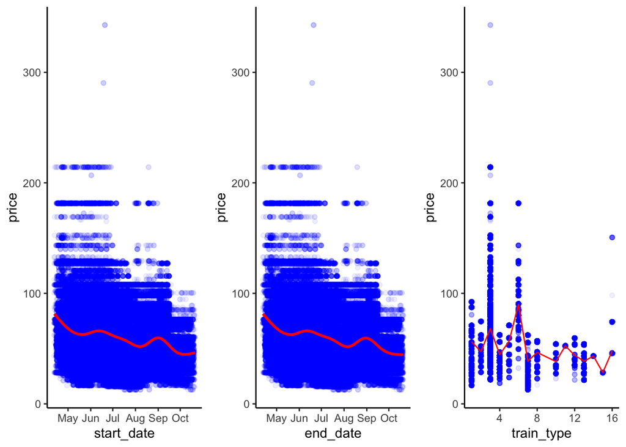

```r
grid.arrange(plot4, plot5, plot6, ncol=3, nrow=1)
```

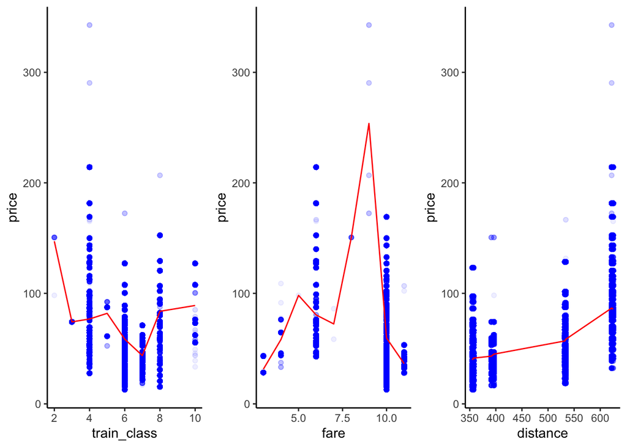

```r
grid.arrange(plot7, plot8, plot9, ncol=3, nrow=1)
```

Se puede contemplar cómo no forman una distribución lineal, por tanto, se van a realizar modelos de regresión no lineal, para ver el cambio. Se comenzará utilizando una función logarítmica, ya que, se vio anteriormente que se aproximaba el precio a la logarítmica:

```r
library(ggplot2)
library(tidyverse)
library(caret)
theme_set(theme_classic())

#discretizacion de variables nominales
must_convert<-sapply(reducedRenfeDF,is.factor)       # logical vector telling if a variable needs to be displayed as numeric
renfeDF2<-sapply(reducedRenfeDF[,must_convert],unclass)    # data.frame of all categorical variables now displayed as numeric
reducedRenfeDF2<-cbind(reducedRenfeDF[,!must_convert],renfeDF2)        # complete data.frame with all variables put together


#60& entrenamiento y 20% test
set.seed(123)
training.samples <- reducedRenfeDF2$price %>%
  createDataPartition(p = 0.6, list = FALSE)
train.data  <- reducedRenfeDF2[training.samples, ]
test.data <- reducedRenfeDF2[-training.samples, ]

# Build the model
model <- lm(price ~ log(distance), data = train.data)
# Make predictions
predictions <- model %>% predict(test.data)
# Model performance
data.frame(
  RMSE = RMSE(predictions, test.data$price),
  R2 = R2(predictions, test.data$price)
)
```

| RMSE | R2 |
| --- | --- |
| 18.83857 | 0.466638 |

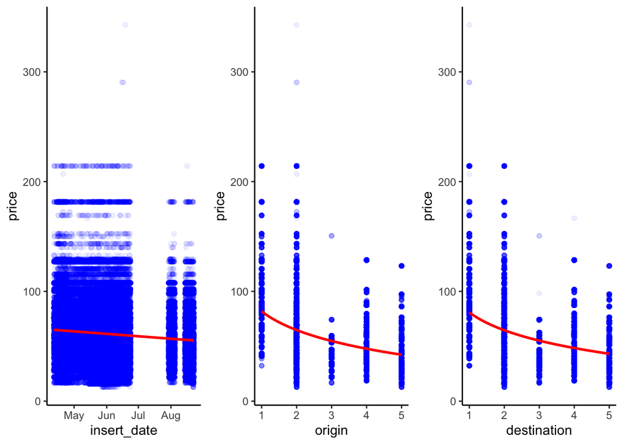

```r
remove(renfeDF2)
remove(reducedRenfeDF2)

plot1 <- ggplot(train.data, aes(x=insert_date, y=price)) +
geom_point(alpha = 1/15, color = 'blue')+
stat_smooth(color = 'Red', method = lm, formula = y ~ log(x))

plot2 <- ggplot(train.data, aes(x=origin, y=price)) +
geom_point(alpha = 1/15, color = 'blue')+
stat_smooth(color = 'Red', method = lm, formula = y ~ log(x))

plot3 <- ggplot(train.data, aes(x=destination, y=price)) +
geom_point(alpha = 1/15, color = 'blue')+
stat_smooth(color = 'Red', method = lm, formula = y ~ log(x))

plot4 <- ggplot(train.data, aes(x=start_date, y=price)) +
geom_point(alpha = 1/15, color = 'blue')+
stat_smooth(color = 'Red', method = lm, formula = y ~ log(x))

plot5 <- ggplot(train.data, aes(x=end_date, y=price)) +
geom_point(alpha = 1/15, color = 'blue')+
stat_smooth(color = 'Red', method = lm, formula = y ~ log(x))

plot6 <- ggplot(train.data, aes(x=train_type, y=price)) +
geom_point(alpha = 1/15, color = 'blue')+
stat_smooth(color = 'Red', method = lm, formula = y ~ log(x))

plot7 <- ggplot(train.data, aes(x=train_class, y=price)) +
geom_point(alpha = 1/15, color = 'blue')+
stat_smooth(color = 'Red', method = lm, formula = y ~ log(x))

plot8 <- ggplot(train.data, aes(x=fare, y=price)) +
geom_point(alpha = 1/15, color = 'blue')+
stat_smooth(color = 'Red', method = lm, formula = y ~ log(x))

plot9 <- ggplot(train.data, aes(x=distance, y=price)) +
geom_point(alpha = 1/15, color = 'blue')+
stat_smooth(color = 'Red', method = lm, formula = y ~ log(x))

library(gridExtra)
grid.arrange(plot1, plot2, plot3, ncol=3, nrow=1)
```

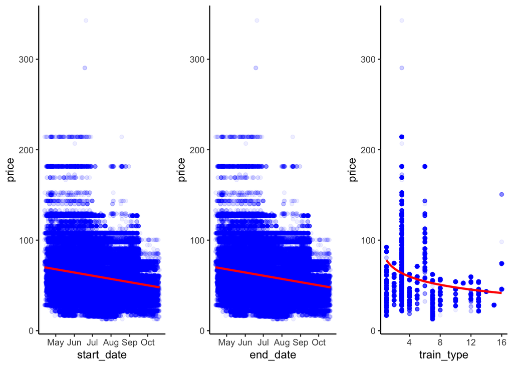

```r
grid.arrange(plot4, plot5, plot6, ncol=3, nrow=1)
```

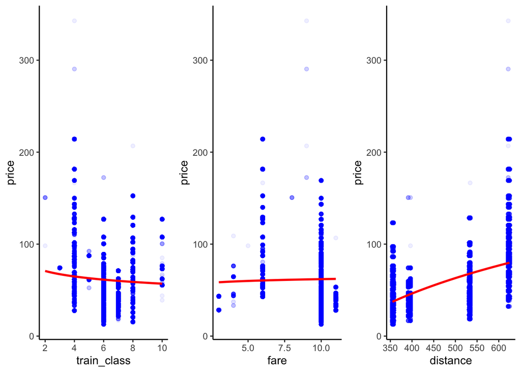

```r
grid.arrange(plot7, plot8, plot9, ncol=3, nrow=1)
```

Ahora polynomial

```r
library(ggplot2)
library(tidyverse)
library(caret)
theme_set(theme_classic())

#discretizacion de variables nominales
must_convert<-sapply(reducedRenfeDF,is.factor)       # logical vector telling if a variable needs to be displayed as numeric
renfeDF2<-sapply(reducedRenfeDF[,must_convert],unclass)    # data.frame of all categorical variables now displayed as numeric
reducedRenfeDF2<-cbind(reducedRenfeDF[,!must_convert],renfeDF2)        # complete data.frame with all variables put together



#60& son entrenamiento y 40% test
set.seed(123)
training.samples <- reducedRenfeDF2$price %>%
  createDataPartition(p = 0.6, list = FALSE)
train.data  <- reducedRenfeDF2[training.samples, ]
test.data <- reducedRenfeDF2[-training.samples, ]

# Build the model
model <- lm(price ~ poly(distance, 5, raw = TRUE), data = train.data)
# Make predictions
predictions <- model %>% predict(test.data)
# Model performance
data.frame(
  RMSE = RMSE(predictions, test.data$price),
  R2 = R2(predictions, test.data$price)
)
```

| RMSE | R2 |
| --- | --- |
| 17.48034 | 0.5407738 |

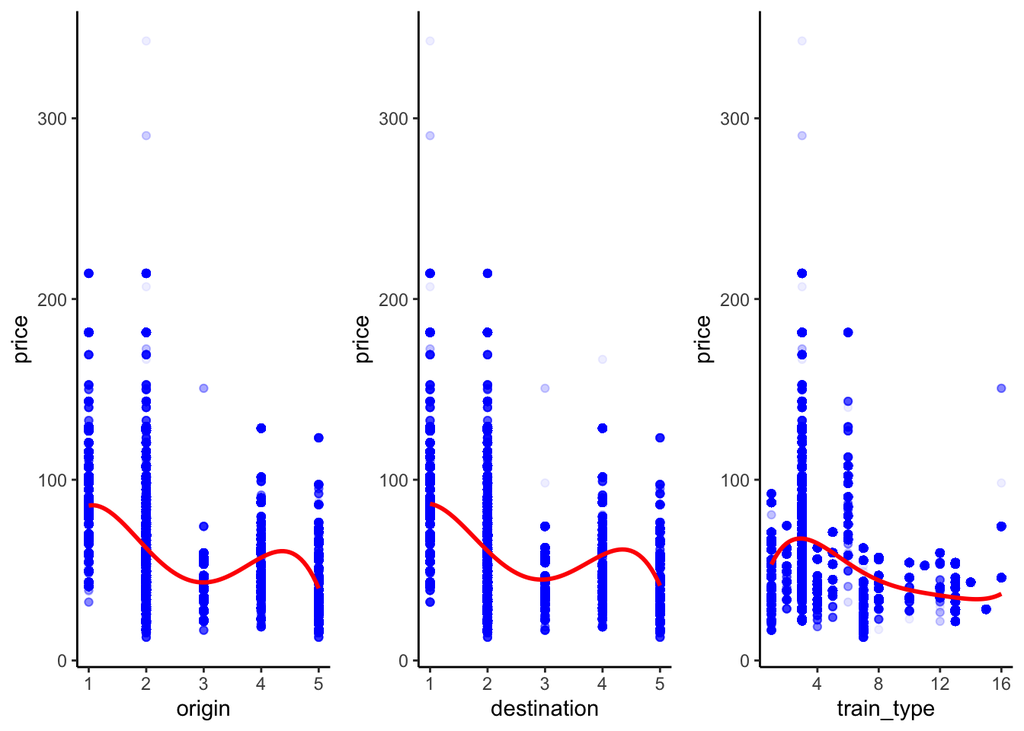

```r
remove(renfeDF2)
remove(reducedRenfeDF2)




plot1 <- ggplot(train.data, aes(x=origin, y=price) ) +
geom_point(alpha = 1/15, color = 'blue')+
stat_smooth(color = 'Red', method = lm, formula = y ~ poly(x, 5, raw = TRUE))

plot2 <- ggplot(train.data, aes(x=destination, y=price) ) +
geom_point(alpha = 1/15, color = 'blue')+
stat_smooth(color = 'Red', method = lm, formula = y ~ poly(x, 5, raw = TRUE))


plot3 <- ggplot(train.data, aes(x=train_type, y=price) ) +
geom_point(alpha = 1/15, color = 'blue')+
stat_smooth(color = 'Red', method = lm, formula = y ~ poly(x, 5, raw = TRUE))

plot4 <- ggplot(train.data, aes(x=train_class, y=price) ) +
geom_point(alpha = 1/15, color = 'blue')+
stat_smooth(color = 'Red', method = lm, formula = y ~ poly(x, 5, raw = TRUE))

plot5 <- ggplot(train.data, aes(x=fare, y=price) ) +
geom_point(alpha = 1/15, color = 'blue')+
stat_smooth(color = 'Red', method = lm, formula = y ~ poly(x, 5, raw = TRUE))

plot6 <- ggplot(train.data, aes(x=distance, y=price) ) +
geom_point(alpha = 1/15, color = 'blue')+
stat_smooth(color = 'Red', method = lm, formula = y ~ poly(x, 5, raw = TRUE))

library(gridExtra)
grid.arrange(plot1, plot2, plot3, ncol=3, nrow=1)
```

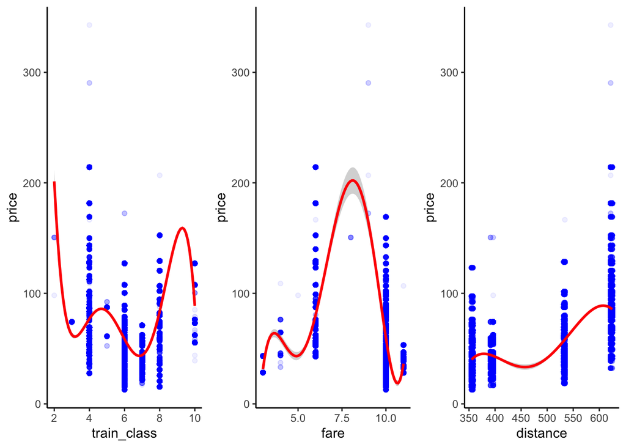

```r
grid.arrange(plot4, plot5, plot6, ncol=3, nrow=1)
```